# Tarea sesion 3

## Carga de datos

Primero cargamos los datos y los evaluamos

```r
dataset=read.table("student-por.csv", sep=";", header=TRUE)
names(dataset)
```

```
##  [1] "school"     "sex"        "age"        "address"    "famsize"
##  [6] "Pstatus"    "Medu"       "Fedu"       "Mjob"       "Fjob"
## [11] "reason"     "guardian"   "traveltime" "studytime"  "failures"
## [16] "schoolsup"  "famsup"     "paid"       "activities" "nursery"
## [21] "higher"     "internet"   "romantic"   "famrel"     "freetime"
## [26] "goout"      "Dalc"       "Walc"       "health"     "absences"
## [31] "G1"         "G2"         "G3"
```

```r
#head(dataset)
#summary(dataset)
```

```r
#primero evaluamos la variable target
#summary(dataset$G3)
#prop.table(table(dataset$G3))
dataset$aprueba <- ifelse(dataset$G3 >=10, 1, 0)
```

```r
#vemos el porcentaje de aprobados (1) y suspensos (0)
prop.table(table(dataset$aprueba))
```

```
##
##         0         1
## 0.1540832 0.8459168
```

```r
table(dataset$G3)
```

```
##
##   0   1   5   6   7   8   9  10  11  12  13  14  15  16  17  18  19
##  15   1   1   3  10  35  35  97 104  72  82  63  49  36  29  15   2
```

Realizamos una matriz de correlación De donde ya podemos concluir que las notas del segundo y tercer cuatrimestre están más correladas entre sí, que las del primer y tercer cuatrimestre. Y que a la vez las notas de primer cuatrimestre y del segundo estan muy correladas entre si, por lo tanto podríamos eliminar de nuestro dataset las notas G1 puesto que no aportarían nada nuevo al modelo.

```r
#Calculamos la matriz de correlacion con todas las variables numericas

MC<- cor(dataset[, c("absences", "Medu", "Fedu", "freetime", "studytime", "failures", "G1", "G2", "G3", "aprueba")])
MC
```

```
##               absences         Medu         Fedu     freetime   studytime
## absences   1.000000000 -0.008577495  0.029858664 -0.018716028 -0.11838937
## Medu      -0.008577495  1.000000000  0.647476609 -0.019686298  0.09700583
## Fedu       0.029858664  0.647476609  1.000000000  0.006840631  0.05039965
## freetime  -0.018716028 -0.019686298  0.006840631  1.000000000 -0.06882922
## studytime -0.118389370  0.097005833  0.050399648 -0.068829222  1.00000000
## failures   0.122778835 -0.172210287 -0.165915005  0.108994622 -0.14744055
## G1        -0.147149242  0.260472290  0.217500651 -0.094496606  0.26087538
## G2        -0.124744933  0.264035300  0.225138930 -0.106677927  0.24049800
## G3        -0.091379056  0.240150757  0.211799679 -0.122704926  0.24978869
## aprueba   -0.087482807  0.144802596  0.146249058 -0.093349398  0.16511082
##             failures          G1         G2          G3     aprueba
## absences   0.1227788 -0.14714924 -0.1247449 -0.09137906 -0.08748281
## Medu      -0.1722103  0.26047229  0.2640353  0.24015076  0.14480260
## Fedu      -0.1659150  0.21750065  0.2251389  0.21179968  0.14624906
## freetime   0.1089946 -0.09449661 -0.1066779 -0.12270493 -0.09334940
## studytime -0.1474405  0.26087538  0.2404980  0.24978869  0.16511082
## failures   1.0000000 -0.38421048 -0.3857822 -0.39331555 -0.38023717
## G1        -0.3842105  1.00000000  0.8649816  0.82638712  0.56306953
## G2        -0.3857822  0.86498163  1.0000000  0.91854800  0.59225119
## G3        -0.3933155  0.82638712  0.9185480  1.00000000  0.66315684
## aprueba   -0.3802372  0.56306953  0.5922512  0.66315684  1.00000000
```

## Clustering jerárquico

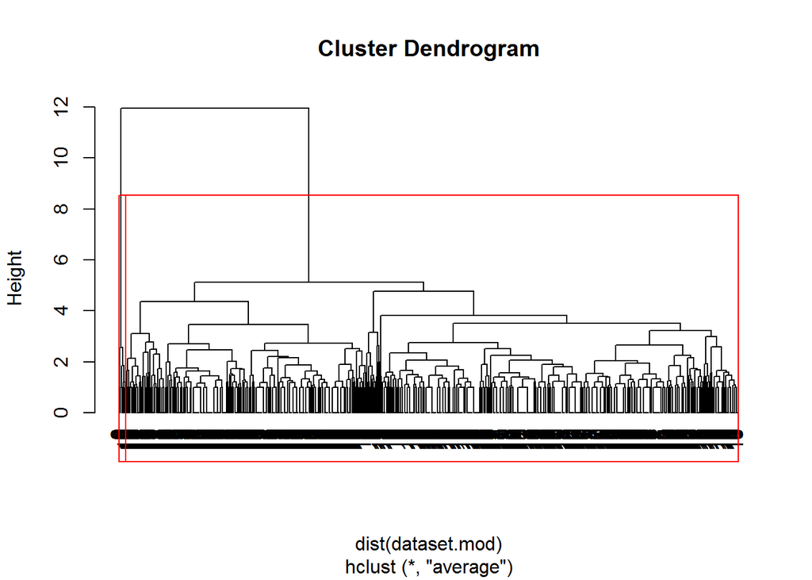

```r
dataset.mod<-cbind(dataset$G2, dataset$Medu, dataset$Fedu, dataset$studytime, dataset$fretime)
#voy a realizar mi modelo solo con las variables G2, Medu, Fedu y studytime
#head(dataset.mod)

set.seed(234)
hc.clust <- hclust(dist(dataset.mod), method="ave")
plot(hc.clust, hang = -1, labels= dataset$G3)

rect.hclust(hc.clust,k=2)
```

```r
#cutree(hc.clust, k=2)
```

En el clustering jerárquico no podemos apreciar nada, salvo que la mayor division esta en dos grupos, dada la naturaleza de los datos me aventuraría a decir que el grupo pequeño es el de los alumnos que obtienen un 0 o 1, y luego estarían el resto